# NNC Thresholds

Gabriel Herrick

March 21, 2015

If we consider all lakes, and look for the highest allowable values for each in the state of FL, we find that the maximum N and P values for a lake are Nmax = 2.23 mg/L and Pmax = 0.49 mg/L. Thus, the NNC Nmax:Pmax ratio is 2.23:0.49 = 4.55:1. We have a very similar, constant ratio Ntreat:Ptreat = 2.240:0.496 = 4.52. Because our N:P ratio is constant in our treatments and commensurate with the NNC N:P ratio, we can use either N or P to calculate the nutrient loading in our treatments as a proportion of the maximum allowable nutrients according to the Numeric Nutrient Criteria (NNCmax). Thus, our High treatment = 2.24/2.23 = 1.00 NNCmax; our Low treatment = 0.42/2.23 = 0.188 NNCmax. Our control of plain tap water will be considered 0 mg/L = 0 NNCmax.

# Nutrient Levels

```r
library(ggplot2)

treat.high.N <- 2.24
treat.low.N <- 0.42
treat.high.P <- 0.50
treat.low.P <- 0.093

NNC.N <- 2.23
NNC.P <- 0.49


dat <- data.frame(
  treatment= factor(c("Tap", "Low", "High"), levels = c("Tap", "Low", "High")),
  Nitrogen = c(0, treat.low.N, treat.high.N),
  Phosphorus = c(0, treat.low.P, treat.high.P)
  )
```

Bar Graphs

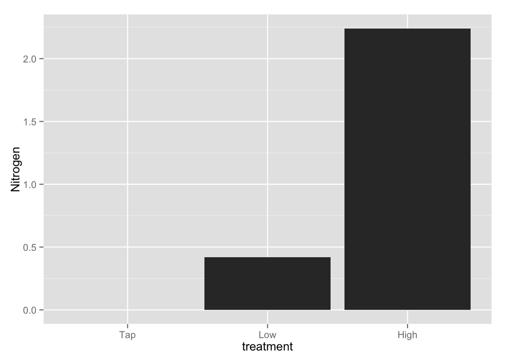

```r
# very basic bar graph
ggplot(data = dat, aes(x=treatment, y=Nitrogen))+
  geom_bar(stat="identity")
```

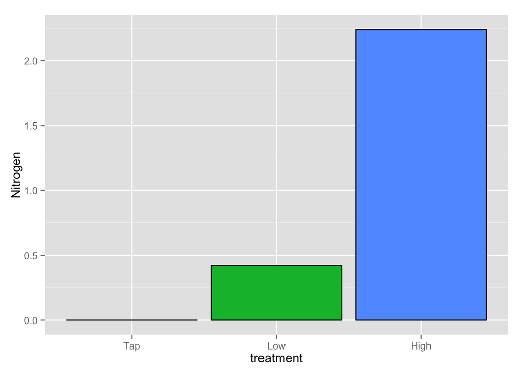

```r
# map treatment to different fill colors, add black line, no legend
ggplot(data = dat, aes(x=treatment, y=Nitrogen, fill = treatment))+
  geom_bar(color="black", stat="identity")+
  guides(fill=FALSE)
```

To draw multiple lines, the points must be grouped by a variable; otherwise all points will be connected by a single line. In this case, we want them to be grouped by nutrient. This means we need to modify the data frame.

```r
Nitrogen <- c(0, treat.low.N, treat.high.N)
Phosphorus <- c(0, treat.low.P, treat.high.P)
N.rel <- (Nitrogen/NNC.N)*100
P.rel <- (Phosphorus/NNC.P)*100

data <- data.frame(
  treatment= factor(rep(c("Tap", "Low", "High"),2), levels = c("Tap", "Low", "High")),
  nutrient = factor(rep(c("nitrogen", "phosphorus"), each=3)),
  concentration = c(N.rel,P.rel)
  )
```

Now that the data frame is modified, we can make the line graph with multiple lines.

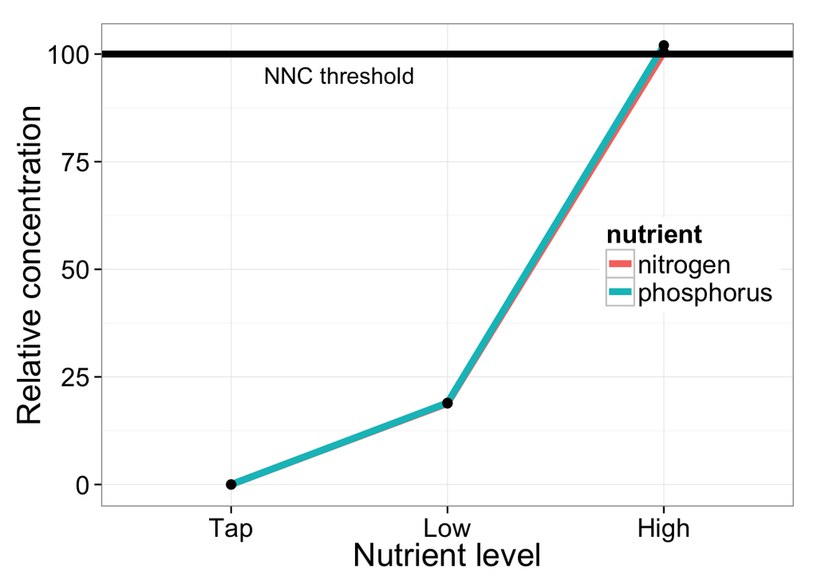

```r
# Basic line graph

line.plot <- ggplot(data=data, aes(x=treatment, y=concentration, group=nutrient)) +
    geom_line(aes(color=nutrient), size=2) +
    geom_point(size=3, fill="white")+
    xlab("Nutrient level") + ylab("Relative concentration")+
    geom_hline(aes(yintercept=100), size = 2)+
    #theme(axis.title.x=element_text(size=20))+
  #theme(axis.text.x = element_text(size=20))+
    #theme(axis.title.y=element_text(size=20))+
  #theme(axis.text.y = element_text(size=20))+
  annotate("text", x = 1.5, y = 95, label = "NNC threshold")+
  theme_bw(base_size=20)+
  theme(legend.position=c(.85, .50))

line.plot
```

Print line plot to file

```r
png("TreatmentLevels.png")
# or tiff("plot.tiff")
print(line.plot)
dev.off()
```